# Classification

Masum Billah

2026-05-28

### K-Nearest Neighbors (KNN)

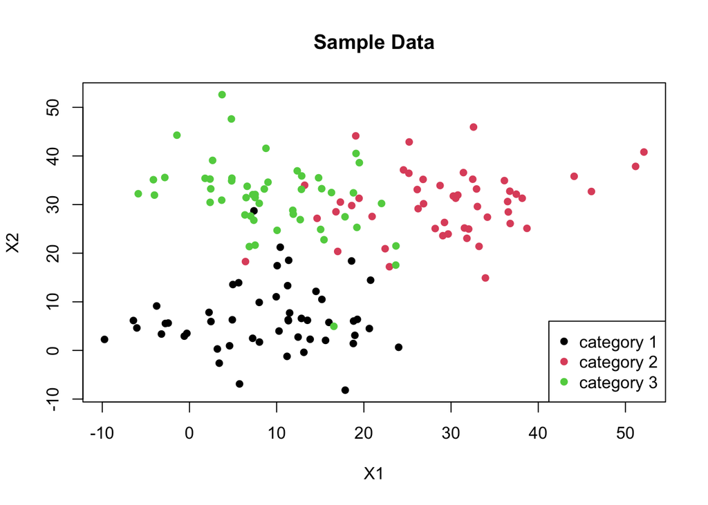

```r
library(MASS)
set.seed(1234)

#sample sizes for the three categories 1, 2, and 3:

n=50
n1=n
n2=n
n3=n
#means for the three categories
mu_x1=10
mu_y1=10
mu_x2=30
mu_y2=30
mu_x3=10
mu_y3=30
sd0=60 #SD

#generate values for sample 1:
d1=mvrnorm(n1,mu=c(mu_x1,mu_y1),Sigma=sd0*diag(2))
d2=mvrnorm(n2,mu=c(mu_x2,mu_y2),Sigma=sd0*diag(2))
d3=mvrnorm(n3,mu=c(mu_x3,mu_y3),Sigma=sd0*diag(2))
dd=rbind(d1,d2,d3)
dd=cbind(dd,c(rep(1,n1),rep(2,n2),rep(3,n3)))
plot(dd[,1:2],col=dd[,3],xlab="X1",ylab="X2",main="Sample Data",pch=16)
legend("bottomright",c("category 1","category 2","category 3"),col=1:3,pch=16)
```

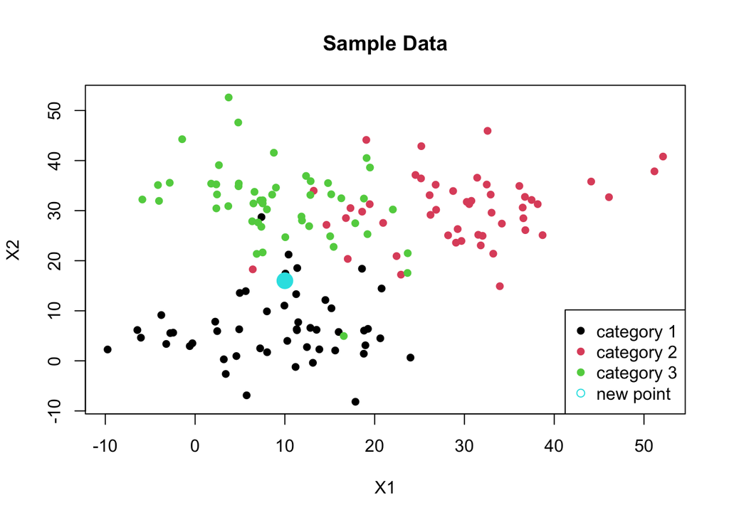

```r
newpoint=c(10,16)

plot(dd[,1:2],col=dd[,3],xlab="X1",ylab="X2",main="Sample Data",pch=16)
points(newpoint[1],newpoint[2],pch=19,col=5,cex=2)
legend("bottomright",c("category 1","category 2","category 3","new point"),col=c(1:3,5),pch=c(16,16,16,1))
```

```r
my_knn <- function(tdat, npoint, K){
  distvec=sqrt((npoint[1]-tdat[,1])^2+(npoint[2]-tdat[,2])^2)
  return(names(sort(table(tdat[order(distvec),3][1:K]), decreasing=T)[1]))
}

newpoint=c(-5,-5)
my_knn(dd, newpoint, 5)
```

```
## [1] "1"
```

# Decision Tree

## Building the tree

There are numerous algorithms for building trees. The basic steps are

1. Start with all variables at the root node.
2. Try all variables and select the one that best separates the classes.
3. Divide the data according to the rule determined in step 2.
4. Repeat 2,3 recursively until a stopping criterion is reached.
5. Apply class labels to the leaf nodes by majority vote.

## Criterion for selecting the best variable to split on

The obvious criterion for choosing the best variable to split on is classification error rate. Since class is predicted by majority vote, this means that the classification error rate is simply the proportion of training observations in the split region that are not of the majority class. The error rate $E_{mn}$ when in region $m$ of the sample space (where regions correspond to tree splits) is

$$E_m=1-\max_{k}(\hat{\rho}_{mk})$$

Where $\hat{\rho}_{km}$ is the proportion of observations in the region $m$ that belong to class $k$. We then calculate $E_m$ across regions. The split that produces the lowest $E_m$’s is the best one.

However, it turns out that the error rate is not sufficiently sensitive for tree building. Instead, a commonly used criterion is the **Ginni index**:

$$G_m=\sum_{k=1}^{K}\hat{\rho}_{mk}(1-\hat{\rho}_{mk})=1-\sum_{k=1}^{K}\hat{\rho}_{mk}^2$$

This has its maximum when $\hat{\rho}_{ik}=0.5$ and minimum when $\hat{\rho}_{ik}$ is one or zero.

The Gini index for a split is the weighted average of the two regions produced by the splits:

$$G_{split}=\frac{n_1}{n}G_1+\frac{n2}{n}G_2$$

$n_1$ and $n_2$ are the number of points on each side of the spit, $n=n_1+n_2$, and $G_1$ and $G_2$ are the Gini indexes for the regions created by the split.

### Algorithm for choosing the split

Here is the basic algorithm: **loop x over remaining predictors**  
**{**  
**loop c over values of split point for x**  
**{**  
**Calculate and store the Gini index for two regions made by (x,c)**  
**}**  
**}**

**optimal (x,c) is the one that produces the smallest Gini index. Take x as the variable and c as the boundary for the split for that variable.**

A common choice for the sequence of values to check at the split points is the midpoints between the values of variable `x` for each pair of data points.

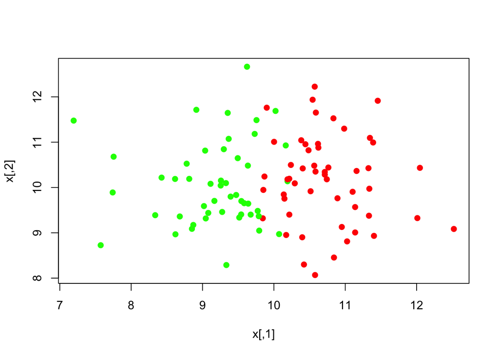

```r
# Tree
set.seed((299))
library(MASS)
n=100
x=mvrnorm(n,mu=c(10,10),Sigma=matrix(c(1,0,0,1),nrow=2))
class=ifelse(x[,1]+rnorm(n,sd=0.25)>10,1,2)
plot(x,col=ifelse(class==1,"red","green"),pch=19)
```

```r
dat = data.frame(x, class)

calcGini <- function(dat, x, y, b){

  class = dat[, y]

  n = nrow(dat)

  # left node probabilities
  p11 = sum(class[dat[,x] <= b] == 1) / sum(dat[,x] <= b)
  p21 = sum(class[dat[,x] <= b] == 2) / sum(dat[,x] <= b)

  # right node probabilities
  p12 = sum(class[dat[,x] > b] == 1) / sum(dat[,x] > b)
  p22 = sum(class[dat[,x] > b] == 2) / sum(dat[,x] > b)

  # gini impurities
  G1 = 1 - p11^2 - p21^2
  G2 = 1 - p12^2 - p22^2

  # node sizes
  n1 = sum(dat[,x] <= b)
  n2 = n - n1

  # weighted impurity
  GSX1 = (n1/n)*G1 + (n2/n)*G2

  return(GSX1)
}

x = 1
y = 3
b = 10

calcGini(dat, x, y, b)
```

```
## [1] 0.1471795
```

```r
bvals <- function(z){
  zvals = sort(z)
  return(head(zvals, -1) + diff(zvals)/2)
}


z = c(2,5,8)
bvals(z)
```

```
## [1] 3.5 6.5
```

```r
find_split <- function(dat, predcol, y){
  Ginivals = matrix(NA, nrow = nrow(dat)-1, ncol = length(predcol))
  j = 0

  for (pc in predcol){
    j = j + 1

    bvec = bvals(dat[, pc])

    i = 0
    for(b in bvec){
      i = i + 1
      Ginivals[i, j] = calcGini(dat, pc, y, b)
    }
  }

  minind = which(Ginivals == min(Ginivals, na.rm = TRUE), arr.ind = TRUE)

  best_col_index = minind[1, 2]
  bestvar = predcol[best_col_index]

  best_b_index = minind[1, 1]
  bestbound = bvals(dat[, bestvar])[best_b_index]

  return(list(
    "best variable to split on" = bestvar,
    "best split point" = bestbound,
    "minimum Gini" = min(Ginivals, na.rm = TRUE)
  ))
}

find_split(dat = dat, predcol = 1:2, y = 3)
```

```
## $`best variable to split on`
## [1] 1
##
## $`best split point`
## [1] 9.81928
##
## $`minimum Gini`
## [1] 0.07428571
```

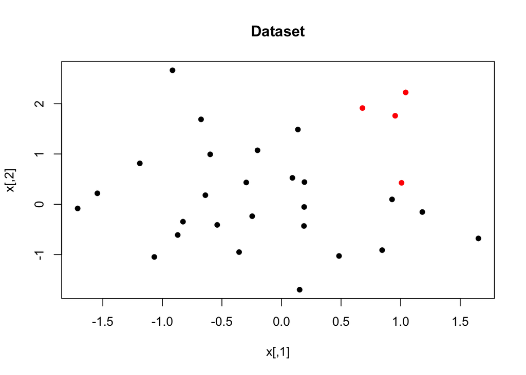

```r
#########

set.seed(299)
n = 30
x = matrix(rnorm(n*2), ncol = 2)
y = ifelse((x[,1] > 0.3) & (x[,2] > 0.3), 1, 2)

plot(
  x,
  col = ifelse(y == 1, "red", "black"),
  pch = 16,
  main = "Dataset"
)
```

```r
# Create dataframe
dat = data.frame(
  X1 = x[,1],
  X2 = x[,2],
  class = y
)

# Apply find_split
fs = find_split(
  dat = dat,
  predcol = 1:2,
  y = 3
)

fs
```

```
## $`best variable to split on`
## [1] 2
##
## $`best split point`
## [1] 1.724858
##
## $`minimum Gini`
## [1] 0.1141026
```

```r
### Read data
library(tidyverse)
library(readxl)

#data = read_csv("./Data_Feces2025.xlsx")
dt_feces =  read_excel("./Data_Feces2025.xlsx", sheet = 2)
dt_rumen = read_excel("./Data_Rumen2025.xlsx", sheet = 2)
sum(colnames(dt_feces) %in% colnames(dt_rumen))
```

```
## [1] 262
```

```r
# dt_combined <- rbind(dt_feces, dt_rumen)
dt_combined <- dplyr::bind_rows(dt_feces, dt_rumen)
#dt_combined <- dt_combined[, colSums(dt_combined != 0, na.rm = TRUE) > 0]
dt_combined <- dt_combined[, colSums(dt_combined != 0) > 0]
head(dt_combined)
```

```
## # A tibble: 6 × 262
##   SampleID  Plate SampType FeedCost  RADG   RFI RADGClass RFIClass StartWt EndWt
##   <chr>     <dbl> <chr>       <dbl> <dbl> <dbl> <chr>     <chr>      <dbl> <dbl>
## 1 Sample_2…     3 Feces        480. -0.24  1.37 2MidRADG  2MidRFI      803  1084
## 2 Sample_2…     3 Feces        412.  0.12 -0.18 2MidRADG  2MidRFI      769  1079
## 3 Sample_2…     3 Feces        371.  0.32 -3.39 2MidRADG  1LowRFI      672   957
## 4 Sample_2…     3 Feces        468. -0.29 -1.7  2MidRADG  1LowRFI      689   934
## 5 Sample_2…     3 Feces        483. -0.37  0.55 1LowRADG  2MidRFI      787  1055
## 6 Sample_2…     3 Feces        467.  0.12  0.81 2MidRADG  2MidRFI      716  1003
## # ℹ 252 more variables: ADG <dbl>, FatCover <dbl>, DMI <dbl>, Raw_FG <dbl>,
## #   Adj_FG <dbl>, RumenpH <dbl>, Absconditicoccaceae <dbl>,
## #   Acetobacteraceae <dbl>, Acholeplasmataceae <dbl>, Acidaminococcaceae <dbl>,
## #   Actinomycetaceae <dbl>, Acutalibacteraceae <dbl>, Akkermansiaceae <dbl>,
## #   Aminobacteriaceae <dbl>, Amoebophilaceae <dbl>, Anaerofustaceae <dbl>,
## #   Anaerolineaceae <dbl>, Anaeroplasmataceae <dbl>, Anaerotignaceae <dbl>,
## #   Anaerovoracaceae <dbl>, Aneurinibacillaceae <dbl>, Aristaeellaceae <dbl>, …
```

### Prepare the dataset for training and testing

```r
set.seed(1)

clean_data = dplyr::select(dt_combined, -starts_with("UnidentifiedFamily"))

X_insample = clean_data[, 16:ncol(clean_data)]
y_insample = as.factor(clean_data$RFIClass)

idx <- sample(1:nrow(X_insample), 0.8 * nrow(X_insample))

train.X <- X_insample[idx, ]
test.X  <- X_insample[-idx, ]
y_train <- y_insample[idx]
y_test  <- y_insample[-idx]
```

## knn function in R

```r
library(class)
X = X_insample
y = y_insample
#knn.predk1=knn(train.X, test.X, Direction.train, k=1)
knn.predk1=knn(X, X, y, k=1)
```

The output from `knn` is the predicted categories for the test data:

```r
knn.predk1[1:30]
```

```
##  [1] 2MidRFI  2MidRFI  1LowRFI  1LowRFI  2MidRFI  2MidRFI  1LowRFI  1LowRFI
##  [9] 1LowRFI  3HighRFI 2MidRFI  1LowRFI  1LowRFI  3HighRFI 2MidRFI  2MidRFI
## [17] 2MidRFI  1LowRFI  2MidRFI  2MidRFI  1LowRFI  3HighRFI 2MidRFI  1LowRFI
## [25] 2MidRFI  2MidRFI  2MidRFI  1LowRFI  1LowRFI  1LowRFI
## Levels: 1LowRFI 2MidRFI 3HighRFI
```

Make a table of the predicted versus actual test values:

```r
table(knn.predk1, y)
```

```
##           y
## knn.predk1 1LowRFI 2MidRFI 3HighRFI
##   1LowRFI       29       0        0
##   2MidRFI        0      68        0
##   3HighRFI       0       0       38
```

```r
mean(knn.predk1 == y)
```

```
## [1] 1
```

Repeat with `k=3`:

```r
knn.predk3=knn(X, X, y, k=3)
table(knn.predk3,y)
```

```
##           y
## knn.predk3 1LowRFI 2MidRFI 3HighRFI
##   1LowRFI       17       3        3
##   2MidRFI        8      57       14
##   3HighRFI       4       8       21
```

```r
mean(knn.predk3==y)
```

```
## [1] 0.7037037
```

```r
knn.predk1=knn(train.X, test.X, y_train, k=1)
table(knn.predk1, y_test)
```

```
##           y_test
## knn.predk1 1LowRFI 2MidRFI 3HighRFI
##   1LowRFI        2       5        7
##   2MidRFI        1       6        6
##   3HighRFI       0       0        0
```

```r
mean(knn.predk1==y_test)
```

```
## [1] 0.2962963
```

```r
knn.predk1=knn(train.X, test.X, y_train, k=3)
table(knn.predk1, y_test)
```

```
##           y_test
## knn.predk1 1LowRFI 2MidRFI 3HighRFI
##   1LowRFI        1       3        4
##   2MidRFI        2       7        8
##   3HighRFI       0       1        1
```

```r
mean(knn.predk1==y_test)
```

```
## [1] 0.3333333
```